# class17: t-tests and bootstrapping t-tests

## We are working with iris data

Familiarize yourself with the [data](https://www.statology.org/iris-dataset-r/)!

We will use `iris` data. We are interesting the `sepal.length` column, and it’s difference across 2 different species

Sources: [flower image](http://www.sunnysimplelife.com/2012/03/spring.html) ; [flower diagram](https://en.wikipedia.org/wiki/Sepal)

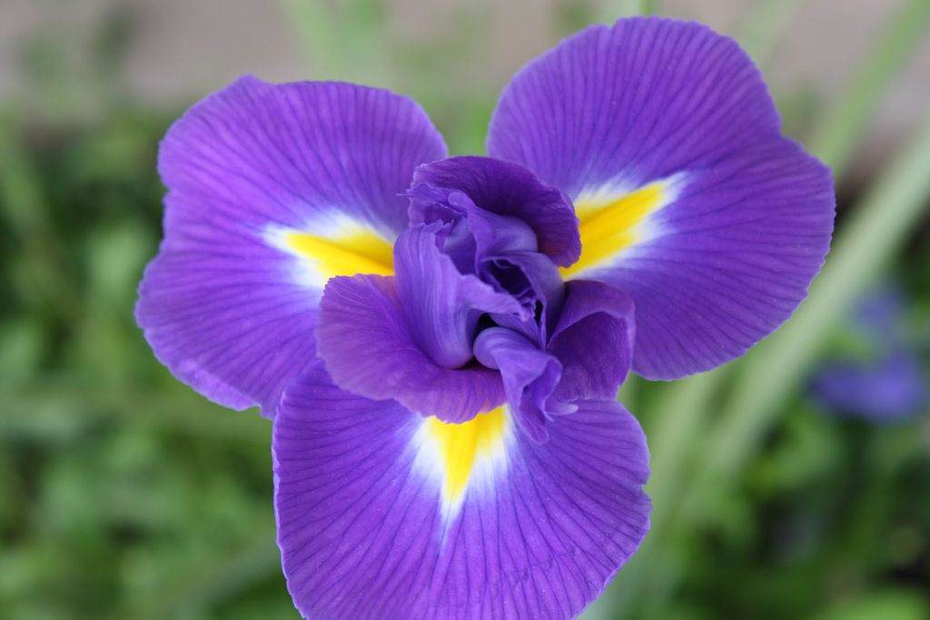

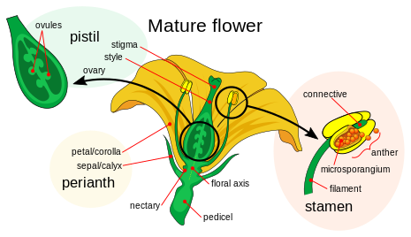

## Setup

Loading libraries and such

```r
library(tidyverse) # data manipulation + plotting
iris <- iris # get dataset into environment
```

## Processing data a.k.a. data wrangling

Apart from the identifiers (the `Species` column), we only need the `Sepal.Length` column to run the t-test on. And we need to `filter` out only 2 species: `virginica` and `versicolor`. We need only 2 species *since t-test can only compare 2 things ; for comparing more species, explore doing ANOVA below)*

```r
iris2 <-
  select(iris, Sepal.Length, Species) %>% # select the required columns

  filter(str_detect(Species, 'virginica|versicolor')) %>% # filter 2 species
  # str_detect() enables matching of strings using regular expressions

  group_by(Species) # use grouping for future bootstrapping by species
```

the [`str_detect()`](https://stringr.tidyverse.org/reference/str_detect.html) function is one nice way of filtering for multiple column name matches using regular expression `patterns`.

The alternate way to filter would be to use this (*it is more verbose!)* -

`filter(Species == 'virginica' | Species == 'versicolor')`

## Do a t-test

Use the R function `t.test()` to do a t-test. Explore the parameters within this function and see how the P-values change when you change them. Important one is the `alternative` ; try going between `two-sided`, `less` and `greater` and understand the results

```r
t.test(Sepal.Length ~ Species, data = iris2)
```

```
    Welch Two Sample t-test

data:  Sepal.Length by Species
t = -5.6292, df = 94.025, p-value = 1.866e-07
alternative hypothesis: true difference in means between group versicolor and group virginica is not equal to 0
95 percent confidence interval:
 -0.8819731 -0.4220269
sample estimates:
mean in group versicolor  mean in group virginica
                   5.936                    6.588
```

The very very low p-value from the t-test ( = 1e-7) implies that the two species differ statistically significantly from one another.

Pay attention the `alternative hypothesis: ..` section and it will tell you if you were doing a one-sided and two-sided t-test

Other numbers

```r
t.test(Sepal.Length ~ Species, data = iris2, alternative = 'less')
```

```
    Welch Two Sample t-test

data:  Sepal.Length by Species
t = -5.6292, df = 94.025, p-value = 9.331e-08
alternative hypothesis: true difference in means between group versicolor and group virginica is less than 0
95 percent confidence interval:
       -Inf -0.4595885
sample estimates:
mean in group versicolor  mean in group virginica
                   5.936                    6.588
```

This is a one sided t-test. What is the relationship between the p-value of this vs the two-sided t-test?

- You will find the answer in class!

The `report()` function from the `{report}` package gives you a summary of many statistical tests in human interpretable language! - Source: [ANOVA-in-R/statsandr](https://hyp.is/YM2UIOUBEe6DrX_FO21x8A/statsandr.com/blog/anova-in-r/). Let’s try it out!

```r
# save the t-test into a variable
one_side_t <- t.test(Sepal.Length ~ Species, data = iris2, alternative = 'less')

report::report(one_side_t) # use this for a nice succinct report
```

```
Effect sizes were labelled following Cohen's (1988) recommendations.

The Welch Two Sample t-test testing the difference of Sepal.Length by Species
(mean in group versicolor = 5.94, mean in group virginica = 6.59) suggests that
the effect is negative, statistically significant, and large (difference =
-0.65, 95% CI [-Inf, -0.46], t(94.03) = -5.63, p < .001; Cohen's d = -1.16, 95%
CI [-Inf, -0.79])
```

*note the* `difference = -0.65` here, we will overlay this value on the histogram

## Try ANOVA on all 3 species!

This tells you that there are atleast 2 species within the 3 that differ from each other significantly. Note: ANOVA also assumes data is normally distributed, independence and other [such stuff](https://statsandr.com/blog/anova-in-r/#underlying-assumptions-of-anova).

Use this for help - https://statsandr.com/blog/anova-in-r/

```r
oneway.test(Sepal.Length ~ Species, data = iris)
```

```
    One-way analysis of means (not assuming equal variances)

data:  Sepal.Length and Species
F = 138.91, num df = 2.000, denom df = 92.211, p-value < 2.2e-16
```

## Do bootstrapping

Remember: Bootstrapping involves -

- Sampling with replacement. Here you need to re-sample within each of the 2 species types
  - Your re-sample will be the same size as your sample!
- Calculating a summary statistic from each bootstrapped sample. The statistic in this case is the `difference in the means` of the two different species’ bootstrap samples.
- Iterating this process many times. Here we will use 10,000 times

Note: Since our p-value is quite low, we will also repeat the t-test and bootstrapping with data that is closer to get the p-values closer (similar to the python workflow). Hence it is ideal to reshape the data using the `pivot()` family functions to bring each species into a separate column

Outline of the algorithm

1. Grab the two species data separately from the data -> into two columns.
2. For each column run these operations 3-5 below (by putting them in a function)
3. Bootstrapping
   1. Make bootstrapped data for each using `sample()` function
   2. Find the mean of each bootstrapped data ; and the difference in the means
4. Now put the above # 2 into a function
5. Run it `10,000` times while recording result in a tibble using a `map()` family of commands

```r
iris2_wide <-

  # make a serial number column (without this pivot makes a single row!)
  mutate(iris2, index = row_number()) %>%

  # now do the pivoting
  pivot_wider(names_from = Species,
              values_from = Sepal.Length)
```

Ref: Found the use of `row_number()` [here](https://stackoverflow.com/a/12925090/9049673)

```r
#' bootstrapping function for t-tests on 2 groups
#' @param .df grouped tibble, 2 categores in grouping col. Defaults `iris2`
#' @param .column string; name of column for bootstrapping
bootstrapped_mean <- function(.vector, .size = length(.vector))
{

  .boots <-
    sample(.vector, size = .size,
           replace = TRUE)

  # if you want the intermediate bootstrapped data, return `.boot`

  # otherwise will only return the summary measurement
  .means_boot <- mean(.boots)
}


#' get multiple bootstrapped means
#' @param .df grouped tibble, 2 categores in grouping col. Defaults `iris2`
#' @param .column string; name of column for bootstrapping
get_n_boots <- function(.df = iris2_wide,
                        .column = 'versicolor',
                        num_of_boots = 10000)
{
    # isolate the column from the dataset (as a vector, so need two : `[[`)
    .vec <- .df[[.column]]
    .len <- length(.vec)

    # map_dbl returns a vector of numbers
    # better/faster than a for() loop: doesn't do many write operations
    map_dbl(1:num_of_boots,
            ~ bootstrapped_mean(.vec, .len))
}

# test the function with a small bootstrap size
get_n_boots(num_of_boots = 5)
```

```
[1] 5.882 6.062 5.880 5.970 5.872
```

Quick note:

To **generalize** this bootstrapping function to **any column** in any dataset, add a parameter

`.column = Sepal.Length` to the function and use `{.column}` in place of the `Sepal.Length` like this

`bootdat = sample({{.column}}, ..`

Now onto the iteration 10,000 times with the above functions and saving data into a tibble

```r
bootdata <-
  tibble(boot_id = 1:10000,
         mean_versicolor = get_n_boots(),
         mean_virginica = get_n_boots(.column = 'virginica'),

         diff_means = mean_virginica - mean_versicolor
         )
```

## Plot histogram

Show the histogram of the means of the bootstrapping exercise

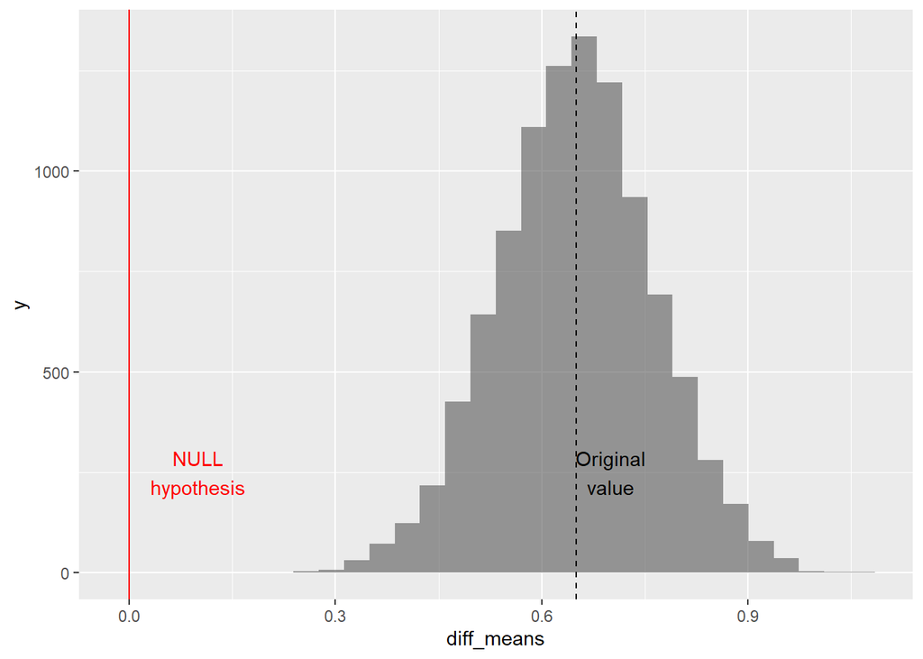

```r
ggplot(bootdata,
       mapping = aes(diff_means)) + geom_histogram(alpha = 0.6) +

  # show the difference in the original sample means
  geom_vline(aes(xintercept = 0.65), linetype = 2) +
  annotate(geom = 'text', x = 0.7, y = 250, label = 'Original\nvalue') +

  # show the NULL hypothesis = 0 difference between means
  geom_vline(aes(xintercept = 0), colour = 'red') +
  annotate(geom = 'text', x = 0.1, y = 250,
           label = 'NULL\nhypothesis', colour = 'red')
```

## Calculate p-value from the bootstrapping

(graphically) You want to area under the tail/subset of the histogram - starting from where 0 intersects towards the more extreme side (away from the peak)

This is the probability that the bootstrapping distribution is more extreme than the NULL hypothesis value. *Mathematically it is the number of diff_means< 0 / total # of points in diff_means*

```r
with(bootdata,
  sum(diff_means < 0) / length(diff_means) )
```

```
[1] 0
```

The result here, 0 is very close the the t-test p-value we got which is 1e-7

# t-test [versicolor + 0.5] with virginica

What happens if we add 0.5 to each element of versicolor (which is the same as adding 0.5 to the bootstrapped mean or reducing 0.5 from the diffmeans!)

- Since the diffmeans come closer together, the p-value calculation will be more interesting and likely closer to the 0.05 threshold

## one-sided t-test

Alternative way to run the `t.test()` function is to refer to two columns within the data for the `x =` and `y =` options. This can be done either using `data$colname` .. or a more succinct way using the with command (*this avoids repeating the data twice for each column)*

```r
t_test_closer <-
  with(data = iris2_wide,
     t.test(x = versicolor + 0.5, y = virginica, alternative = 'greater')
       ) %>%

  print
```

```
    Welch Two Sample t-test

data:  versicolor + 0.5 and virginica
t = -1.3123, df = 94.025, p-value = 0.9037
alternative hypothesis: true difference in means is greater than 0
95 percent confidence interval:
 -0.3444115        Inf
sample estimates:
mean of x mean of y
    6.436     6.588
```

## bootstrapping

```r
# make a new column with versi2
iris2_closer <-
  mutate(iris2_wide, versi2 = versicolor + 0.5)

# bootstrap
boot_closer <-
  tibble(boot_id = 1:10000,
         mean_versi2 = get_n_boots(.df = iris2_closer, .column = 'versi2'),
         mean_virginica = get_n_boots(.column = 'virginica'),

         diff_means = mean_virginica - mean_versi2
         )
```

## histogram

show the same histogram format with the new data

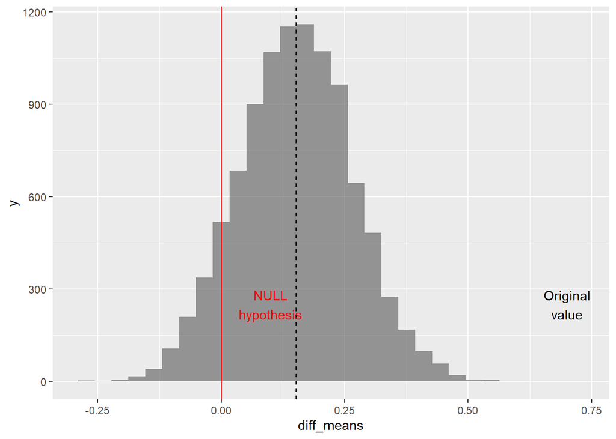

```r
# get the difference of original means to show in the histogram
# in the original data, we used 0.65 from the report. Here let's calculate it again..
orig_diffmean <-
  summarize(iris2_closer, m = mean(virginica - versi2)) %>%
  pull(m)

# ggplot
ggplot(boot_closer,
       mapping = aes(diff_means)) + geom_histogram(alpha = 0.6) +

  # show the difference in the original sample means
  geom_vline(aes(xintercept = orig_diffmean), linetype = 2) +
  annotate(geom = 'text', x = 0.7, y = 250, label = 'Original\nvalue') +

  # show the NULL hypothesis = 0 difference between means
  geom_vline(aes(xintercept = 0), colour = 'red') +
  annotate(geom = 'text', x = 0.1, y = 250,
           label = 'NULL\nhypothesis', colour = 'red')
```

## get p-value

```r
with(boot_closer,

    sum(diff_means < 0) / length(diff_means)
     )
```

```
[1] 0.0964
```

```r
t_test_closer$p.value
```

```
[1] 0.9036967
```

# Doing this quicker using `moderndive` functions

I don’t know how to do this yet, but maybe this [moderndive textbook](https://moderndive.com/7-sampling.html#what-proportion-of-this-bowls-balls-are-red) might help both of us figure it out!

`moderndive::rep_sample_n()` function can make n bootstrapped samples (*probably more efficiently than the manual version above?*)

# (archive) Bootstrapping in long format

If you needed to do bootstrapping directly on the iris2 data, you would do it like this. I went down this path and decided to do wider eventually. But putting this here for reference!

On a side point, this is quite a bit slower than the above function. Tidyverse functions such as `mutate` are not meant to be iterated on 10,000 times!

Outline of the algorithm

1. Grab the two species data separately from the data
2. Make bootstrapped data for each using `sample()` function
3. Find the mean of each bootstrapped data ; and the difference in the means
4. Now put the above (1-3) into a function
5. Run it multiple times while recording result in a tibble using a `map()` command

```r
#' bootstrapping function for t-tests on 2 groups
#' @param .df grouped tibble, 2 categores in grouping col. Defaults `iris2`
#' @param .column name of column to use for bootstrapping
#' @param return_which What do you want to return?
#' 1. `'boots'` -> bootstrapping data
#' 2. 'individual_means' -> show the means of the two different species
#' 3. 'diff_mean' -> Difference between means
boot_difference_means <- function(.df = iris2,
                                  .column = Sepal.Length,
                                  return_which = 'diff_mean')
{
  .boots <-
    mutate(.df,
            bootdat = sample({{.column}}, size = n(),
                             replace = TRUE, ))

  # otherwise will only return the summary measurement
  .means_boot <- summarize(.data = .boots, m = mean(bootdat))

  # calculate difference in means (Species 2 - Species 1)
  diffmean <- .means_boot$m %>% diff()

  # if you want to see the bootstrapped data
  if(return_which == 'boots') return(.boots)

  # if you want to see the individual means
  if(return_which == 'individual_means') return(.means_boot)

  # to see final bootstrapping output = difference of means
  if(return_which == 'diff_mean') return(diffmean)


}

# test the function once
boot_difference_means()
```

```
[1] 0.742
```

Quick note:

To **generalize** this bootstrapping function to **any column** in any dataset, add a parameter

`.column = Sepal.Length` to the function and use `{.column}` in place of the `Sepal.Length` like this

`bootdat = sample({{.column}}, ..`

Now onto the iteration 10,000 times with the above function

```r
# make a numeric vector with the 10,000 values of difference betwn means
diff_means <-
  map_dbl(1:10000, ~ boot_difference_means())
```